# OOP, Klassendiagramm

Objektorientierte Programmierung

## OOP: Blick in die Geschichte …

[figure not shown]

[Quelle: Thomas Woodtli, Wikimedia Commons, CC-BY-SA-2.0](https://creativecommons.org/licenses/by-sa/2.0/deed.en)

- 1960er: **Ole-Johan Dahl** und **Kristen Nygaard** am Norwegian Computing Center in Oslo simulieren Schiffsbewegungen im Osloer Hafen
- Damalige prozedurale Programiersprachen (Algol, Fortran): verfilzter Code; -> **Simula** (OOP)
- 1970er: **Alan Kay** wollte interaktives Computersystem bauen -> Simula -> **Smalltalk** (OOP)

## Geschichte: Schiffe

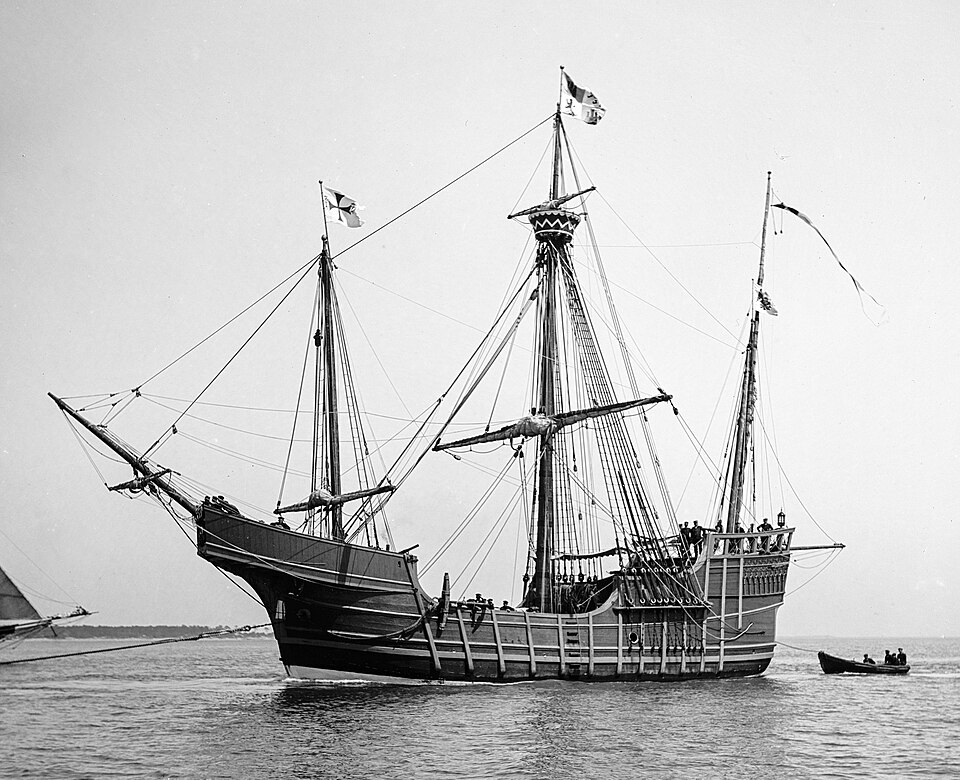

Santa Maria, Schiff von Kolumbus 1492, Wikimedia Commons, vermutlich von Edward H. Hart, public domain

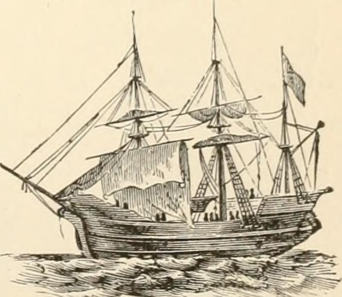

Mayflower, 1620, Wikimedia Commons, CC0 1.0 public domain

## Geschichte: Schiffe

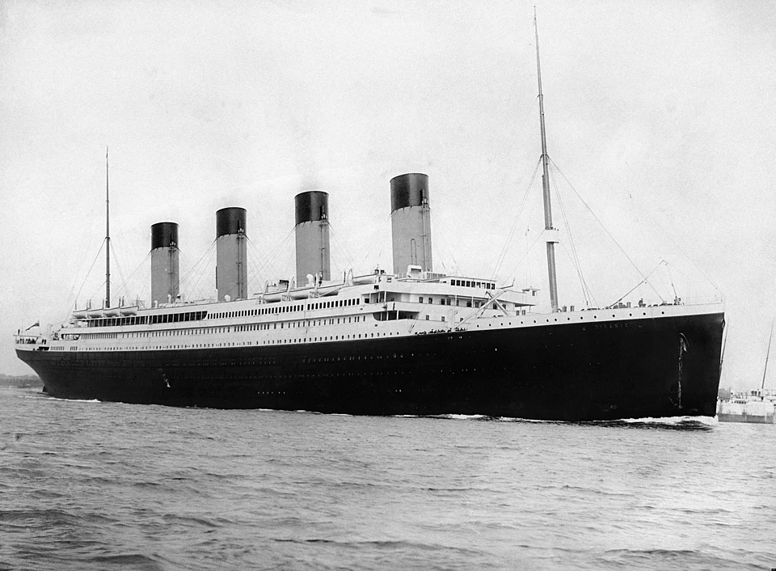

RMS Titanic 1912, Francis Godolphin Osbourne Stuart gest. 1923, Wikimedia Commons, public domain

## Ziele

Grundpfeiler der objektorientierten Programmierung (OOP) verstehen und anwenden können:

- Kapselung, Vererbung, Polymorphie, Interfaces
- UML-Notation
- Zugriffsmodifikatoren
- Einführung in Pseudocode mit OOP-Konzepten

## OOP: Was ist eine Klasse?

- Eine Klasse ist ein **Bauplan für die Erstellung von Objekten.**
- Klasse definiert Attribute und Methoden eines Objekts
  - Attribute: Eigenschaften, Variablen; repräsentieren den **Zustand**
  - Methoden: Funktionen; repräsentieren das **Verhalten**
- Klasse ermöglicht Erstellung **mehrerer Objekte mit ähnlichen Merkmalen und Verhaltensweisen**

## OOP: Was ist ein Objekt?

- eine konkrete Instanz einer Klasse
- besitzt die Attribute und Methoden, die in seiner Klasse definiert sind
- **Jedes Objekt hat seinen eigenen Satz von *Werten* für die Attribute**.
- Attribute -> Zustand des Objekts
- Methoden -> Verhalten des Objekts, das auf diesem Zustand operiert
- **Ein Objekt ist eine Verkapselung von Daten (Zustand) und den dazu gehörenden Operationen (Verhalten).**

## OOP: Grundideen

- Kapselung *(Encapsulation)*
- Vererbung
- Polymorphie
- Interfaces

## OOP: Kapselung *(Encapsulation)*

- interne Daten eines Objekts werden vor direktem Zugriff geschützt
- Zugriff erfolgt über definierte Methoden (Getter/Setter)
- Zugriffsmodifikatoren steuern die Sichtbarkeit:  
  *public, private, protected, package*
- schafft **Datenintegrität**: Manipulation nur auf sichere, kontrollierte Weise
- verbessert **Wartbarkeit**: Änderungen an der internen Implementierung der Klasse beeinflussen nicht die Programmteile, die die Klasse verwenden

## OOP vs. prozedurale Programmierung

### OOP

- Daten und Funktionen werden zu Objekten **zusammengefasst**
- Objekt kann Attribute (Daten) und Methoden (Funktionen) enthalten

### Prozedurale Programmierung

- Programm führt eine Reihe von Aufgaben aus: **Prozeduren**
- Prozeduren operieren auf **Daten**
- Daten sind **getrennt** von Prozeduren; Prozeduren **bearbeiten** die Daten

## Prozedur vs. Funktion

### Funktion

- Codeblock, der eine spezifische Aufgabe ausführt
- **liefert in der Regel einen Wert zurück**

### Prozedur

- Codeblock, der eine spezifische Aufgabe ausführt
- **liefert in der Regel *keinen* Wert zurück**
- Prozedur führt Aufgabe aus und kehrt dann zur aufrufenden Stelle im Code zurück

## OOP: Kapselung - Zugriffsmodifikatoren

Zugriffsmodifikatoren bestimmen, wo auf Klassen, Methoden und Variablen zugegriffen werden kann.

| Zugriffs- modifikator | Symbol |
| --- | --- |
| `public` | + |
| `private` | - |
| `protected` | # |
| `package` | ~ |

| Bedeutung |
| --- |
| Zugriff **überall** erlaubt, sowohl innerhalb als auch außerhalb der Klasse |
| Zugriff **nur innerhalb der Klasse** erlaubt, in der sie definiert sind |
| Zugriff nur innerhalb der Klasse, des Pakets und von abgeleiteten Klassen erlaubt |
| Zugriff ist innerhalb der Klasse und in allen Klassen desselben Pakets erlaubt |

## OOP: Kapselung - Zugriffsmodifikatoren

#### IHK-Standard in Prüfungen

| Zugriffs- modifikator | Symbol | Bedeutung | Verwendung |
| --- | --- | --- | --- |
| `private` | - | Zugriff **nur innerhalb der Klasse** erlaubt, in der sie definiert sind | Attribute |
| `public` | + | Zugriff **überall** erlaubt, sowohl innerhalb als auch außerhalb der Klasse | Operation / Methode |

#### UML-Beispiel

```
+------------------------------+
|          Konto               |
|------------------------------|
| - kontostand: double         |
|------------------------------|
| + getKontostand(): double    |
| + einzahlen(betrag: double)  |
| + abheben(betrag: double)    |
+------------------------------+
```

- Niemand darf direkt auf den Kontostand (`private`) zugreifen und ihn verändern
- Veränderung nur über die `public`-Methoden `einzahlen()` und `abheben()`, die eine **Validierung** durchführen

## OOP: Vererbung

- Schlüsselprinzip: ermöglicht, neue Klassen aus bereits existierenden Klassen zu erzeugen
- eine Klasse *(Kindklasse)* kann Attribute und Methoden einer anderen Klasse *(Elternklasse)* übernehmen
- fördert **Wiederverwendbarkeit** und **Hierarchiebildung**; vermeidet **Redundanz**
- **Kindklasse** heißt auch **abgeleitete Klasse** oder **Unterklasse**
- **Elternklasse** heißt auch **Oberklasse** oder **Basisklasse**

## Vererbung: Python-Beispiel

```python
# Elternklasse = Basisklasse = Oberklasse

class Haustier:
    def __init__(self, name):
        self.name = name
        self._energie = 100  # Unterstrich:
        # Konvention für geschütztes Attribut

    def spielen(self):
      ...
```

```python
# Kindklasse = abgeleitete Klasse = Unterklasse

class Hund(Haustier):
    pass    # erbt alles unverändert
```

```python
# Anwendung

bello = Hund("Bello")
bello.spielen()   # nutzt die geerbte Methode
```

## Vererbung: UML

```
+----------------------------+
|       Fahrzeug             |
|----------------------------|
| # marke: String            |
| # baujahr: int             |
|----------------------------|
| + beschreibung(): String   |
+----------------------------+
         ^            ^
         |            |
    erbt von      erbt von
         |            |
+----------------+  +--------------------+
|     PKW        |  |       LKW          |
|----------------|  |--------------------|
| - anzahlSitze  |  | - ladekapazitaet   |
|----------------|  |--------------------|
| + beschreibung |  | + beschreibung()   |
+----------------+  +--------------------+
```

- `PKW` und `LKW` erben von `Fahrzeug`
- Beide übernehmen die `protected`-Attribute `marke` und `baujahr`
- Beide erhalten jeweils ein eigenes privates Attribut (`anzahlSitze` bzw. `ladekapazität`)

## Vererbung: Begriffe

- **Oberklasse (Superklasse)** – Klasse, von der geerbt wird
- **Unterklasse (Subklasse)** – Klasse, die erbt
- **super** – Zugriff auf Methoden/Konstruktor der Oberklasse
- **Ist-ein-Beziehung** – PKW ist ein Fahrzeug (Vererbung)
- **Hat-ein-Beziehung** – Fahrzeug hat einen Motor (Komposition, keine Vererbung; wird später vertieft)
- Durch Vererbung müssen gemeinsame Attribute (marke, baujahr) und Methoden nur einmal in der Elternklasse definiert werden.
- Kindklassen fügen spezifische Attribute hinzu und können Methoden überschreiben.

## OOP: Polymorphie (“Vielgestaltigkeit”)

**Definition:** Polymorphie (Vielgestaltigkeit) bedeutet, dass Objekte verschiedener Klassen über eine gemeinsame Schnittstelle angesprochen werden können und sich **unterschiedlich verhalten**.

- Wie wird das unterschiedliche Verhalten der Objekte ausgelöst?  
  durch den **Datentyp** oder die **Klasse**
- Klassen teilen Methoden, aber die **Implementierungen** der Methoden können variieren
- Wann wird entschieden, welche Implementierung ausgeführt wird? Zur Laufzeit! Tatsächlicher Objekttyp entscheidet
- verbessert **Flexibilität**
- erhöht **Wiederverwendbarkeit von Code**
- erleichtert **standardisierte Schnittstellen**

## Polymorphie: Zwei Arten

| Art | Beschreibung | Beispiel |
| --- | --- | --- |
| Überladen (*Overloading*) | Gleicher Methodenname, verschiedene Parameter | `berechne(a)` und `berechne(a, b)` |
| Überschreiben (*Overriding*) | Kindklasse überschreibt Methode der Elternklasse | `Hund.sprechen()` statt `Tier.sprechen()` |

## OOP: Schnittstellen *(Interfaces)*

- definieren, **welche** Methoden eine Klasse implementieren muss
- lassen offen, **wie**
- ermöglichen lose Kopplung und Austauschbarkeit von Komponenten

## Schnittstellen: UML-Notation

```
+-------------------+
| <<interface>>     |
| Druckbar          |
|-------------------|
|                   |
|-------------------|
| + drucke(): void  |
+-------------------+
        ^
  implementiert
+-------------------+
| Rechnung          |
|-------------------|
| + drucke(): void  |
+-------------------+
```

## Klassendiagramm

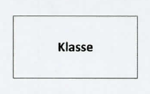

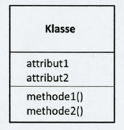

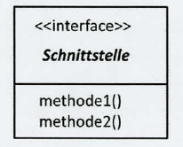

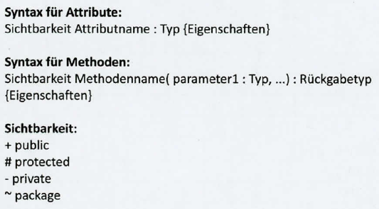

## Klassendiagramm: Beispiel

#### Vererbung & Polymorphie: UML

```
+----------------------------+
|         Haustier           |
|----------------------------|
| - name : String            |
| - energie : int            |
|----------------------------|
| + spielen() : void         |
| + ausruhen() : void        |
+----------------------------+
         ^            ^
         |            |
         |            |
+----------------+  +----------------+
|      Hund      |  |     Katze      |
|----------------|  |----------------|
| + spielen()    |  | + spielen()    |
| + ausruhen()   |  | + ausruhen()   |
+----------------+  +----------------+
```

## Klassendiagramm: Beziehungen

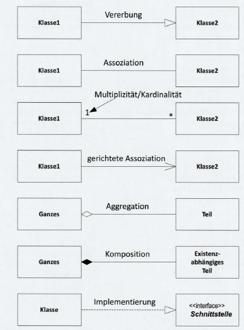

- Vererbung: Pfeil zeigt auf Oberklasse
- Assoziation: Beziehung zwischen Klassen; kann gerichtet oder ungerichtet sein
  - Beispiele ungerichtet: Lehrer - Schüler; Produkt - Kategorie
  - Beispiele gerichtet: Email -> Empfänger; Rechnung -> Kunde
- Aggregation und Komposition: Beziehung Teil - Ganzes
  - Aggregation: Teil kann ohne das Ganze existieren, z. B. Schüler (Teil) - Unterricht
  - Komposition: Teile existenziell vom Ganzen abhängig, z. B. Raum - Haus

## Klassendiagramm: Kardinalitäten

**Definition Kardinalitäten = Multiplizitäten:** Wie viele Instanzen einer Klasse können mit einer Instanz einer anderen Klasse in Beziehung stehen?

| Schreibweise | Bedeutung | Erklärung |
| --- | --- | --- |
| `0..*` oder `*` | Null bis beliebig viele | Die Beziehung ist optional. Es können keine oder unendlich viele Objekte verknüpft sein. |
| `1..*` | Eins bis beliebig viele | Mindestens ein Objekt muss existieren (Pflichtbeziehung). |
| `0..1` | Null oder eins | Optional, aber maximal ein Objekt (z. B. ein Profil für einen Nutzer). |
| `1` oder `1..1` | Genau eins | Exakt ein Objekt muss verknüpft sein |
| `n..m`, z. B. `2..5` | Bestimmte Spanne | Mindestens n und maximal m Objekte |

## Komposition, Aggregation

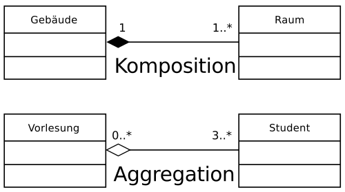

Quelle: Kakashi-Madara, Wikimedia Commons

- Raum kann nicht ohne Gebäude existieren: starke Beziehung, **Komposition**
- Student kann ohne Vorlesung existieren: lose Beziehung, **Aggregation**
- *Kardinalitäten beachten*

## Klassendiagramm: Erläuterung

Das **Klassendiagramm** zeigt Klassen, ihre Attribute und Methoden sowie Beziehungen zwischen Klassen.

- **Klassen und Objekte:** Welche Klassen gibt es und welche Objekte repräsentieren sie?
- **Attribute und Operationen:** Welche Eigenschaften und Verhaltensweisen haben die Klassen?
- **Beziehungen:** Wie sind die Klassen miteinander verknüpft (z. B. durch Assoziationen und Vererbungen)?
- **Sichtbarkeit:** Welche Attribute und Operationen sind öffentlich, privat oder geschützt?
- **Kardinalität:** Wie viele Instanzen einer Klasse können mit einer anderen in Beziehung stehen?

**Viel Erfolg!**

Zurück zur Übersicht LF8